# Data Analysis Skill Test - Case 2

## **Sumário do Dataset**

Data summary

| Name | data |
| --- | --- |
| Number of rows | 117965 |
| Number of columns | 8 |
| _______________________ |  |
| Column type frequency: |  |
| character | 6 |
| numeric | 2 |
| ________________________ |  |
| Group variables | None |

**Variable type: character**

| skim_variable | n_missing | complete_rate | min | max | empty | n_unique | whitespace |
| --- | --- | --- | --- | --- | --- | --- | --- |
| date | 0 | 1 | 10 | 10 | 0 | 276 | 0 |
| product | 0 | 1 | 4 | 12 | 0 | 6 | 0 |
| state | 0 | 1 | 2 | 2 | 0 | 27 | 0 |
| country | 0 | 1 | 4 | 32 | 0 | 212 | 0 |
| type | 0 | 1 | 6 | 6 | 0 | 2 | 0 |
| route | 0 | 1 | 3 | 6 | 0 | 5 | 0 |

**Variable type: numeric**

| skim_variable | n_missing | complete_rate | mean | sd | p0 | p25 | p50 | p75 | p100 | hist |
| --- | --- | --- | --- | --- | --- | --- | --- | --- | --- | --- |
| tons | 0 | 1 | 14536.81 | 49779.26 | 0 | 124.9 | 2000 | 13534.03 | 1798446 | ▇▁▁▁▁ |
| usd | 0 | 1 | 4813150.34 | 19494115.59 | 0 | 71552.0 | 725000 | 3895943.00 | 903930411 | ▇▁▁▁▁ |

## **Questionários**

### 1. Show the evolution of total monthly and total annual exports from Brazil (all states and to everywhere) of ‘soybeans’, ‘soybean oil’ and ‘soybean meal’;

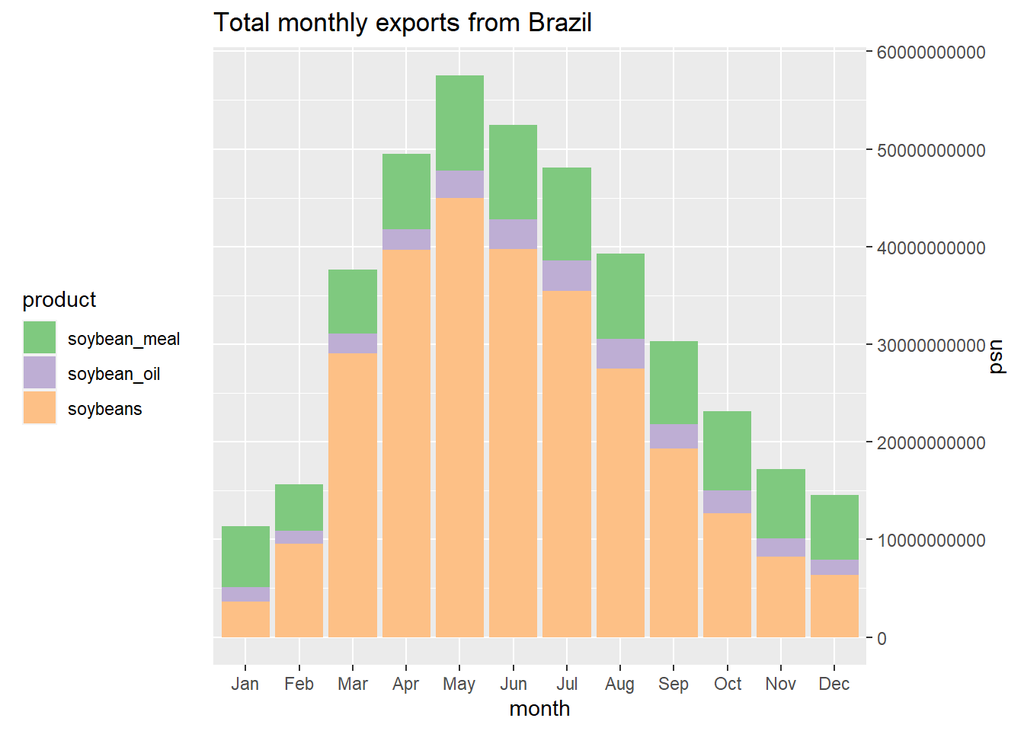

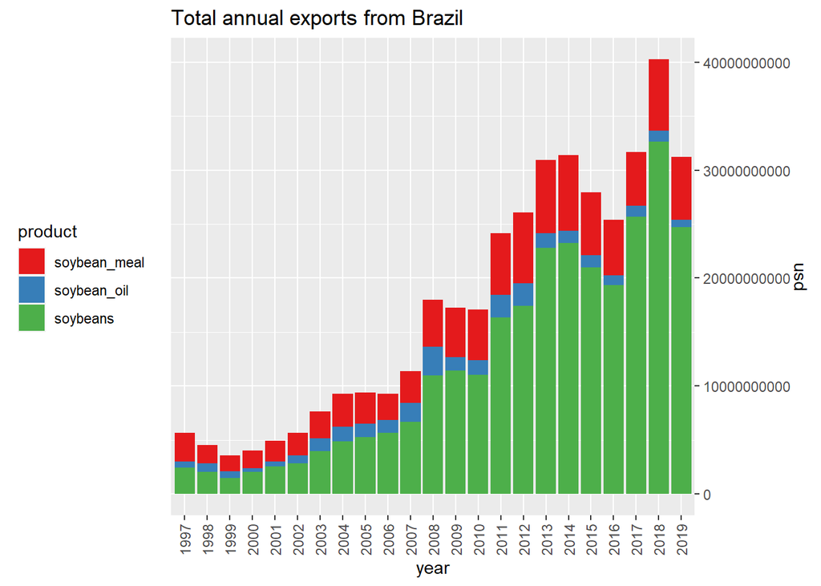

### 2. What are the 3 most important products exported by Brazil in the last 5 years?

Irei atribuir o total do valor dos produtos exportados como indicador para saber quais são os mais importantes que foram exportados do Brasil nos últimos 5 anos.

```
## # A tibble: 3 x 2
##   product               usd
##   <chr>               <dbl>
## 1 soybeans     123325529857
## 2 sugar         40938486021
## 3 soybean_meal  28407723437
```

Como resultado acima, soybeans, sugar e soybean_meal foram os 3 produtos exportados pelo Brasil mais importantes nos últimos 5 anos.

### 3. What are the main routes through which Brazil have been exporting ‘corn’ in the last few years? Are there differences in the relative importance of routes depending on the product?

```
## # A tibble: 3 x 2
##   route      tons
##   <chr>     <dbl>
## 1 Sea   90023406.
## 2 River  3500016.
## 3 Other   262436.
```

As rotas principais que o Brasil exportou milho foram Sea, River e Other nos últimos 3 anos.

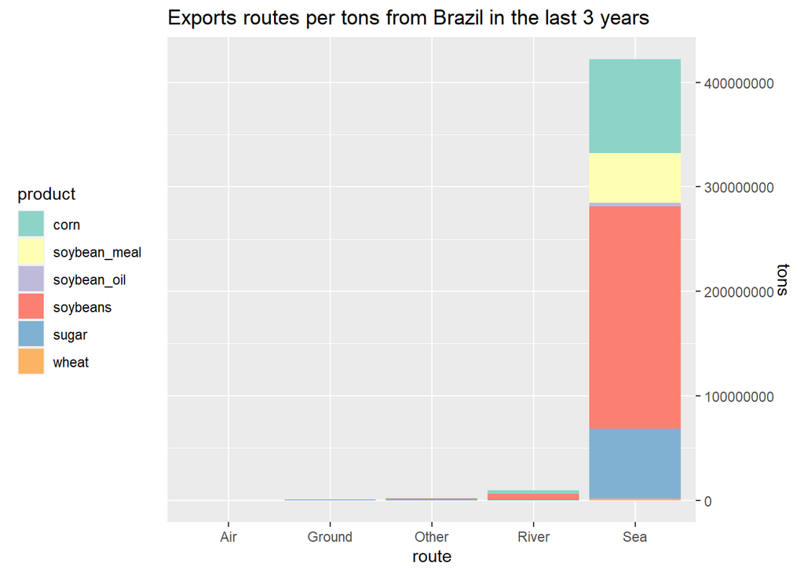

Conforme o gráfico acima, fica claro que a rota por mar é o tipo de rota que o Brasil mais utiliza para exportar todos os tipos de produtos listados no dataset. Não havendo assim, nenhuma diferença significativa entre as rotas conforme o tipo de produto.

### 4. Which countries have been the most important trade partners for Brazil in terms of ‘corn’ and ‘sugar’ in the last 3 years?

```
## # A tibble: 5 x 2
##   country           usd
##   <chr>           <dbl>
## 1 Iran       3302427878
## 2 Bangladesh 2591053578
## 3 Algeria    2441462244
## 4 Egypt      2385649201
## 5 Malaysia   1735364581
```

Conforme tabela acima, Iran, Bangladesh e Algeria são os maiores parceiros comerciais que o Brasil tem, com relação ao total de vendas (exportação) de corn e sugar dos últimos 3 anos.

### 5. For each of the products in the dataset, show the 5 most important states in terms of exports?

```
##         product state   usd_total
## 1          corn    MT 28375516035
## 2          corn    PR  9160511995
## 3          corn    GO  5706990655
## 4          corn    MS  3405430680
## 5          corn    SP  1511121926
## 6  soybean_meal    MT 27994539842
## 7  soybean_meal    PR 24649962821
## 8  soybean_meal    RS 15007385729
## 9  soybean_meal    GO  9421430703
## 10 soybean_meal    BA  5439265638
## 11  soybean_oil    PR 11109102057
## 12  soybean_oil    RS  6281965055
## 13  soybean_oil    MT  5434513926
## 14  soybean_oil    SC  1238810673
```

[output cut: 16 more lines]

Conforme resultado acima, trouxe os 5 estados mais importantes com relação ao montante de venda de exportação para cada produto do dataset.

## **Time Series Forecast**

### 6. Now, we ask you to show your modelling skills. Feel free to use any type of modelling approach, but bear in mind that the modelling approach depends on the nature of your data, and so different models yield different estimates and forecasts. To help you out in this task we also provide you with a dataset of possible covariates (.xlsx). They all come from public sources (IMF, World Bank) and are presented in index number format. Question: What should be the total brazilian soybeans, soybean_meal, and corn export forecasts, in tons, for the next 11 years (2020-2030)? We’re mostly interested in the annual forecast.

##### Corn Exports Time Series

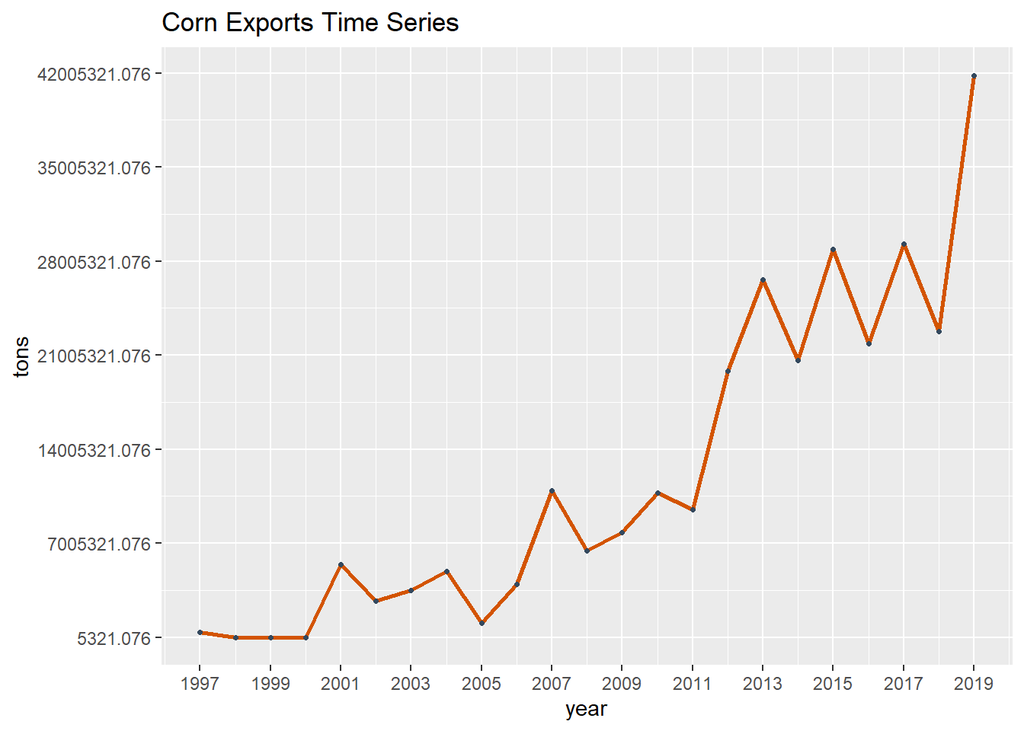

Prevendo toneladas de corn para os próximos 11 anos

Resultado sumarizado para produto Corn:

```
## Series: ss$tons[ss$product == "corn"]
## ARIMA(1,1,0) with drift
##
## Coefficients:
##           ar1      drift
##       -0.7215  1588877.1
## s.e.   0.1863   610293.3
##
## sigma^2 estimated as 25549887975615:  log likelihood=-370.12
## AIC=746.25   AICc=747.58   BIC=749.52
##
## Training set error measures:
##                     ME    RMSE     MAE       MPE     MAPE      MASE        ACF1
## Training set -34962.13 4713522 3621820 -5582.242 5602.022 0.7533187 -0.06031409
```

Método utilizado pelo ARIMA automático:

```
## [1] "ARIMA(1,1,0) with drift"
```

Forecast do modelo

```
##    Point Forecast    Lo 80    Hi 80    Lo 95    Hi 95
## 24       30797508 24319663 37275354 20890499 40704518
## 25       41494154 34769790 48218517 31210126 51778181
## 26       36511730 28025843 44997618 23533685 49489775
## 27       42841834 33923576 51760091 29202536 56481131
## 28       41009892 31021250 50998534 25733582 56286202
## 29       45066907 34568374 55565440 29010786 61123028
## 30       44875010 33587510 56162510 27612269 62137752
## 31       47748725 35935014 59562435 29681213 65816236
## 32       48410585 35950113 60871058 29353937 67467233
## 33       50668309 37692915 63643704 30824156 70512463
## 34       51774610 38235329 65313891 31068067 72481153
```

Plotando a previsão na série temporal junto com intervalo de confiança de 80% e 95%

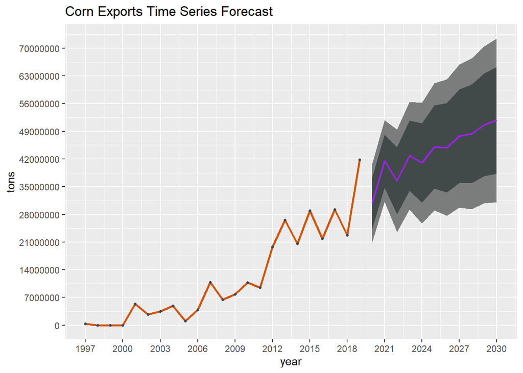

##### Soybeans Exports Time Series

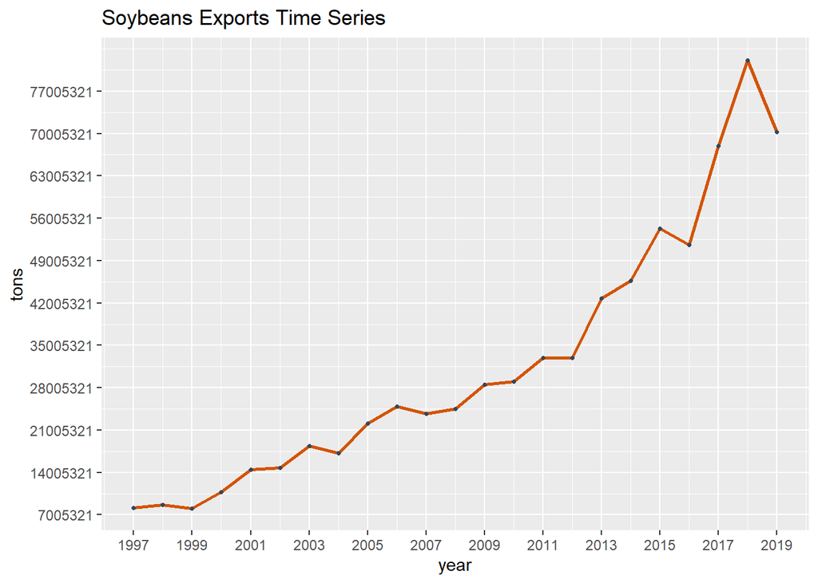

Prevendo toneladas de soybeans para os próximos 11 anos

Resultado sumarizado para produto soybeans:

```
## Series: ss$tons[ss$product == "soybeans"]
## ARIMA(0,1,0) with drift
##
## Coefficients:
##         drift
##       2822960
## s.e.  1223948
##
## sigma^2 estimated as 34530908393418:  log likelihood=-373.61
## AIC=751.21   AICc=751.84   BIC=753.4
##
## Training set error measures:
##                    ME    RMSE     MAE       MPE     MAPE      MASE       ACF1
## Training set 233.5679 5615000 3823088 -4.175806 11.89947 0.8634138 -0.2063914
```

Método utilizado pelo ARIMA automático:

```
## [1] "ARIMA(0,1,0) with drift"
```

Forecast do modelo

```
##    Point Forecast    Lo 80     Hi 80    Lo 95     Hi 95
## 24       73123105 65592322  80653887 61605767  84640442
## 25       75946065 65295930  86596199 59658090  92234040
## 26       78769025 65725327  91812722 58820411  98717638
## 27       81591985 66530420  96653549 58557310 104626660
## 28       84414945 67575604 101254286 58661395 110168494
## 29       87237905 68791331 105684478 59026305 115449505
## 30       90060865 70136288 109985441 59588854 120532875
## 31       92883825 71583556 114184093 60307875 125459774
## 32       95706785 73114438 118299131 61154772 130258797
## 33       98529744 74715320 122344169 62108725 134950764
## 34      101352704 76375926 126329483 63154017 139551391
```

Plotando a previsão na série temporal junto com intervalo de confiança de 80% e 95%

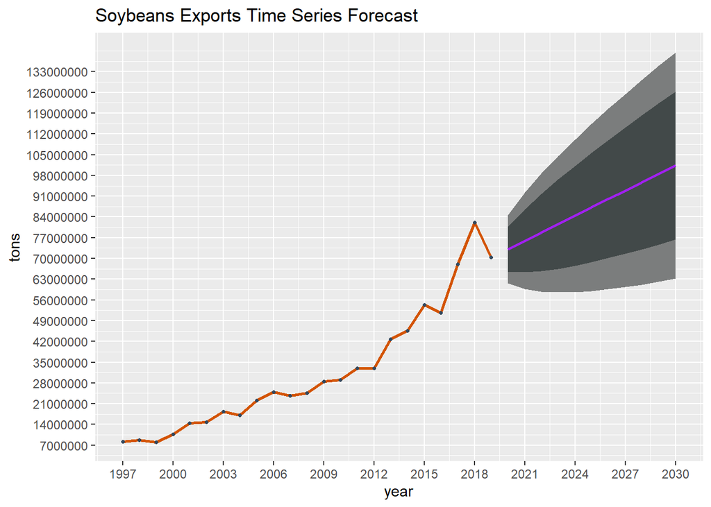

##### Soybean_meal Exports Time Series

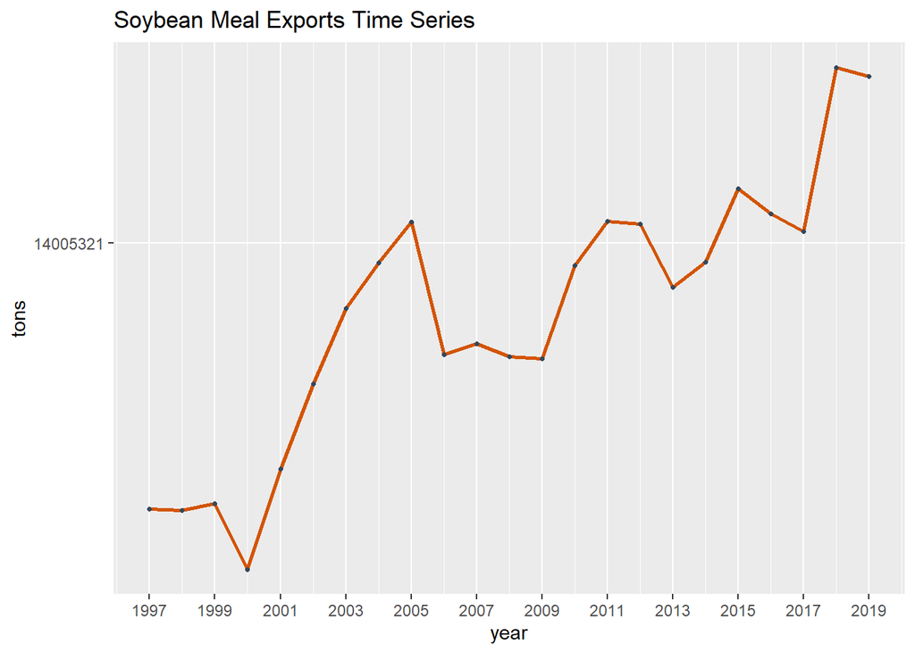

Prevendo toneladas de soybean_meal para os próximos 11 anos

Resultado sumarizado para produto soybean_meal:

```
## Series: ss$tons[ss$product == "soybean_meal"]
## ARIMA(0,1,0)
##
## sigma^2 estimated as 1022111092297:  log likelihood=-335.4
## AIC=672.8   AICc=673   BIC=673.89
##
## Training set error measures:
##                    ME     RMSE      MAE      MPE     MAPE      MASE        ACF1
## Training set 285843.5 988772.7 724294.9 1.909083 5.580086 0.9570943 -0.04442368
```

Método utilizado pelo ARIMA automático:

```
## [1] "ARIMA(0,1,0)"
```

Forecast do modelo

```
##    Point Forecast    Lo 80    Hi 80    Lo 95    Hi 95
## 24       16530381 15234738 17826023 14548867 18511895
## 25       16530381 14698066 18362696 13728097 19332665
## 26       16530381 14286262 18774499 13098298 19962464
## 27       16530381 13939096 19121665 12567353 20493409
## 28       16530381 13633236 19427525 12099581 20961181
## 29       16530381 13356718 19704043 11676683 21384079
## 30       16530381 13102433 19958328 11287788 21772974
## 31       16530381 12865751 20195011 10925813 22134949
## 32       16530381 12643454 20417308 10585839 22474923
## 33       16530381 12433200 20627562 10264283 22796478
## 34       16530381 12233221 20827540  9958442 23102319
```

Plotando a previsão na série temporal junto com intervalo de confiança de 80% e 95%

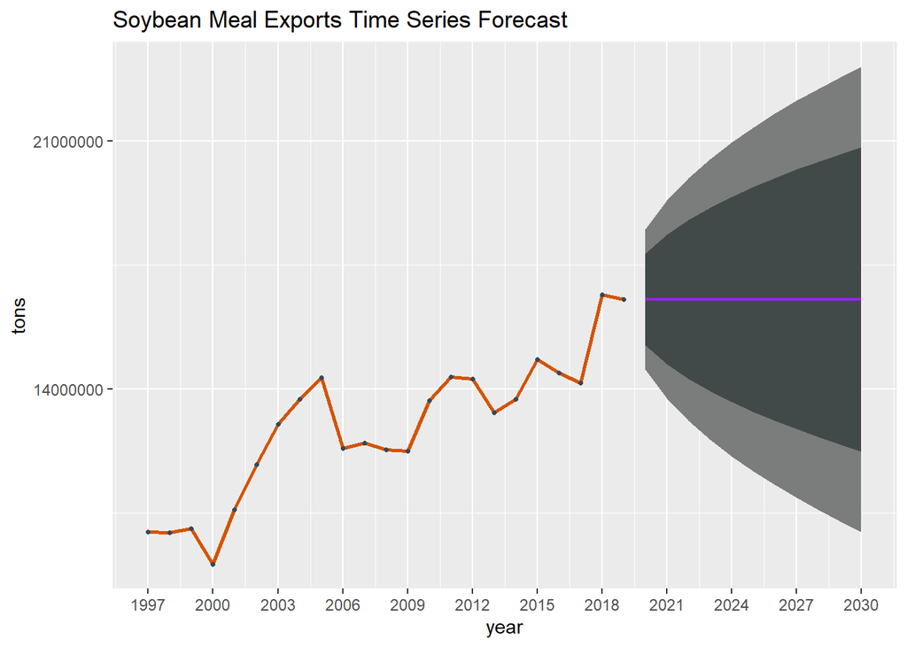